# Les Champs de Sirene

François Sémécurbe

27 novembre 2017

# la librairie SF

“sf” est une librairie pour la manipulation d’objets géographiques tels que les points, les lignes et les polygones. on présente ici un exemple d’utilisation de ces outils pour la représentation des tabacs parisiens on va donc charger à la fois les coordonnées des tabacs et le shapefile des arrondissements de Paris

```r
library(sf)
setwd("/Users/sakarovitch/Documents/insee/trpourlundi")
```

# Chargement des données

```r
tabac=read.csv("tabac.csv",sep=",",as.is=T)
tabac[1:10,]
```

|  | x | y | ARRONDISSEMENT |
| --- | --- | --- | --- |
| 1 | 652975.2 | 6858660 | 75013 |
| 2 | 653202.5 | 6858239 | 75013 |
| 3 | 654837.7 | 6862242 | 75011 |
| 4 | 654536.2 | 6862114 | 75011 |
| 5 | 653856.4 | 6861808 | 75011 |
| 6 | 651274.4 | 6862755 | 75001 |
| 7 | 651200.4 | 6862727 | 75001 |
| 8 | 655489.2 | 6865568 | 75019 |
| 9 | 653185.5 | 6861391 | 75004 |
| 10 | 653610.2 | 6861712 | 75004 |

[output not shown]

1-10 of 10 rows

# Chargement du shapefile

la fonction sf_transform permet de passer d’un système de coordonnées à un autre

```r
arrondissement=st_read("arrondissement.shp")
arrondissement=st_transform(arrondissement, 2154)
arrondissement=arrondissement[order(arrondissement$C_ARINSEE),]
arrondissement[1:5,]
```

```
Simple feature collection with 5 features and 13 fields
geometry type:  POLYGON
dimension:      XY
bbox:           xmin: 650178.9 ymin: 6859831 xmax: 653708.7 ymax: 6863753
epsg (SRID):    NA
proj4string:    +proj=lcc +lat_1=49 +lat_2=44 +lat_0=46.5 +lon_0=3 +x_0=700000 +y_0=6600000 +ellps=GRS80 +units=m +no_defs
   OBJECTID   N_SQ_AR C_AR C_ARINSEE L_AR        L_AROFF   N_SQ_CO NB_POP99 NB_POP08
3         3 750000001    1     75101  1er         Louvre 750001537    16895    17440
9         9 750000002    2     75102 2ème         Bourse 750001537    19640    21793
19       19 750000003    3     75103 3ème         Temple 750001537    34232    34824
12       12 750000004    4     75104 4ème Hôtel-de-Ville 750001537    30671    27977
1         1 750000005    5     75105 5ème       Panthéon 750001537    58841    62143
   NB_POP10 POU_E99_10 SHAPE_Leng SHAPE_Area                       geometry
3     17308   2.444510   6054.681  1824612.9 POLYGON ((650706.580099116 ...
9     23009  17.153768   4553.939   991153.8 POLYGON ((652426.165399145 ...
19    35652   4.148165   4519.072  1170882.9 POLYGON ((653331.96019916 6...
12    28012  -8.669427   5420.637  1600585.6 POLYGON ((653665.11319917 6...
1     60938   3.563842   6238.823  2539374.7 POLYGON ((653357.221899165 ...
```

```
plotting the first 9 out of 13 attributes; use max.plot = 13 to plot all
```

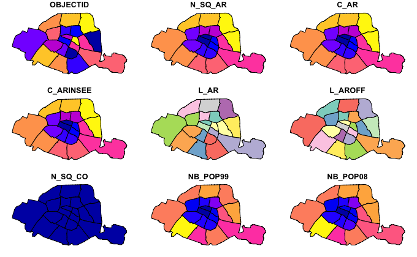

```r
plot(arrondissement)
```

# calcul des coordonnées des centroides

La fonction st_centroid calcul le centre d’un polygone, et la fonction st_coordinates extrait les coordonnées d’un point

```r
coord_arrondissement=(st_coordinates(st_centroid(arrondissement)))
arrondissement$x=coord_arrondissement[,1]
arrondissement$y=coord_arrondissement[,2]
```

# Calcule de distances

utilisation simple

```r
tabac_distance=tabac
distance=((outer(tabac_distance$x,arrondissement$x,"-"))^2+(outer(tabac_distance$y,arrondissement$y,"-"))^2)^0.5
distance=data.frame(distance)
names(distance)=paste0("arr",75001:75020)
tabac_distance=cbind(tabac_distance,distance)
```

# du point à un objet géographique

à partir des coordonnées on cherche à construire un objet géographique, le point. on pourra ensuite représenter les points sur une carte ou tester l’appartenance du point à un autre objet géographique comme le polygone c’est la fonction st_sf qui permet de créer un objet de type sf, objet héritant de la classe des dataframe. Grossièrement il s’agit d’un dataframe avec une colonne supplémentaire contenant une liste de coordonnées, c’est la colonne dite de géométrie. Pour créer donc des objets sf contenant les tabacs comme des points il faut préciser la géométrie de ces objets, c’est à dire fournir une colonne géométrie correspondante. Pour cela on utilise la fonction st_as_sfc qui convertit une géométrie en un objet du package sf. L’option crs désigne le système de coordonnées utilisé.

```r
geometry=st_as_sfc(paste0("POINT (",tabac$x," ",tabac$y,")"),crs=2154)
tabac_sf=st_sf(tabac,geometry=geometry)
tabac_sf[1:10,]
```

```
Simple feature collection with 10 features and 3 fields
geometry type:  POINT
dimension:      XY
bbox:           xmin: 651200.4 ymin: 6858239 xmax: 655489.2 ymax: 6865568
epsg (SRID):    2154
proj4string:    +proj=lcc +lat_1=49 +lat_2=44 +lat_0=46.5 +lon_0=3 +x_0=700000 +y_0=6600000 +ellps=GRS80 +towgs84=0,0,0,0,0,0,0 +units=m +no_defs
          x       y ARRONDISSEMENT                       geometry
1  652975.2 6858660          75013 POINT (652975.1527 6858659....
2  653202.5 6858239          75013 POINT (653202.5086 6858238....
3  654837.7 6862242          75011 POINT (654837.6976 6862242....
4  654536.2 6862114          75011 POINT (654536.1777 6862114....
5  653856.4 6861808          75011 POINT (653856.4185 6861807....
6  651274.4 6862755          75001 POINT (651274.4287 6862755....
7  651200.4 6862727          75001 POINT (651200.4192 6862726....
8  655489.2 6865568          75019 POINT (655489.1984 6865568....
9  653185.5 6861391          75004 POINT (653185.483 6861390.5...
10 653610.2 6861712          75004 POINT (653610.1694 6861712....
```

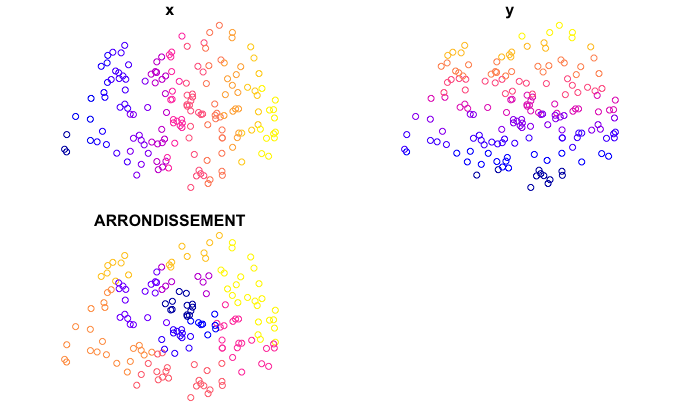

```r
plot(tabac_sf)
```

# Exemples

calcul intersection

```r
contain=st_contains(arrondissement,tabac_sf[1,],sparse=F)
tabac_sf[1,"ARRONDISSEMENT"]
```

```
Simple feature collection with 1 feature and 1 field
geometry type:  POINT
dimension:      XY
bbox:           xmin: 652975.2 ymin: 6858660 xmax: 652975.2 ymax: 6858660
epsg (SRID):    2154
proj4string:    +proj=lcc +lat_1=49 +lat_2=44 +lat_0=46.5 +lon_0=3 +x_0=700000 +y_0=6600000 +ellps=GRS80 +towgs84=0,0,0,0,0,0,0 +units=m +no_defs
  ARRONDISSEMENT                       geometry
1          75013 POINT (652975.1527 6858659....
```

```r
arrondissement$C_ARINSEE[contain]
```

```
[1] 75113
```

matrice de contiguïté

```r
(conti=st_touches(arrondissement,arrondissement,sparse=F))
```

```
       [,1]  [,2]  [,3]  [,4]  [,5]  [,6]  [,7]  [,8]  [,9] [,10] [,11] [,12] [,13] [,14]
 [1,] FALSE  TRUE  TRUE  TRUE  TRUE  TRUE  TRUE  TRUE  TRUE FALSE FALSE FALSE FALSE FALSE
 [2,]  TRUE FALSE  TRUE FALSE FALSE FALSE FALSE FALSE  TRUE  TRUE FALSE FALSE FALSE FALSE
 [3,]  TRUE  TRUE FALSE  TRUE FALSE FALSE FALSE FALSE FALSE  TRUE  TRUE FALSE FALSE FALSE
 [4,]  TRUE FALSE  TRUE FALSE  TRUE  TRUE FALSE FALSE FALSE FALSE  TRUE  TRUE FALSE FALSE
 [5,]  TRUE FALSE FALSE  TRUE FALSE  TRUE FALSE FALSE FALSE FALSE FALSE  TRUE  TRUE  TRUE
 [6,]  TRUE FALSE FALSE  TRUE  TRUE FALSE  TRUE FALSE FALSE FALSE FALSE FALSE FALSE  TRUE
 [7,]  TRUE FALSE FALSE FALSE FALSE  TRUE FALSE  TRUE FALSE FALSE FALSE FALSE FALSE FALSE
 [8,]  TRUE FALSE FALSE FALSE FALSE FALSE  TRUE FALSE  TRUE FALSE FALSE FALSE FALSE FALSE
 [9,]  TRUE  TRUE FALSE FALSE FALSE FALSE FALSE  TRUE FALSE  TRUE FALSE FALSE FALSE FALSE
[10,] FALSE  TRUE  TRUE FALSE FALSE FALSE FALSE FALSE  TRUE FALSE  TRUE FALSE FALSE FALSE
[11,] FALSE FALSE  TRUE  TRUE FALSE FALSE FALSE FALSE FALSE  TRUE FALSE  TRUE FALSE FALSE
[12,] FALSE FALSE FALSE  TRUE  TRUE FALSE FALSE FALSE FALSE FALSE  TRUE FALSE  TRUE FALSE
[13,] FALSE FALSE FALSE FALSE  TRUE FALSE FALSE FALSE FALSE FALSE FALSE  TRUE FALSE  TRUE
[14,] FALSE FALSE FALSE FALSE  TRUE  TRUE FALSE FALSE FALSE FALSE FALSE FALSE  TRUE FALSE
```

[output cut: 27 more lines]

les arrondissements contigus au 20eme

```
n greater than number of different finite values\nn reset to number of different finite valuesn same as number of different finite values\neach different finite value is a separate class
```

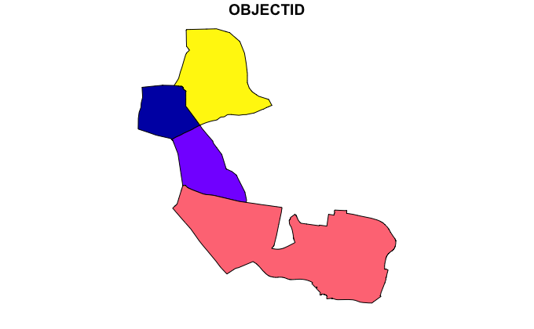

```r
plot(arrondissement[conti[20,],],max.plot=1)
```

# représentation spatiale des points sous la forme d’une nappe spatiale

```r
library(btb)
library(cartography)
tabac$un=1#la variable à lisser
lissage=kernelSmoothing(tabac[,c("x","y","un")],200,2000)
```

[output not shown]

[output cut: 45 more lines]

[output not shown]

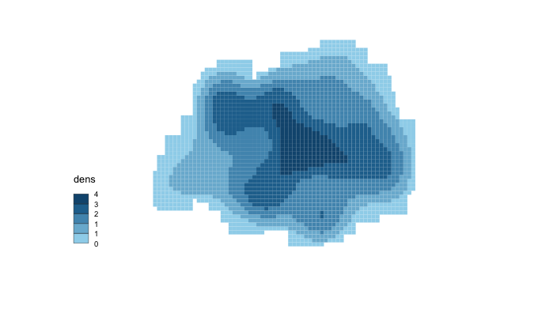

```r
lissage$dens=lissage$un*25#pour recuperer une densite
grid <- st_as_sf(smoothingToGrid(lissage, "2154"))
choroLayer(grid, var = "dens", nclass = 5,method =  "fisher-jenks",border=NA)
```

```
ignoring all but the first attribute
```

[figure not shown]

```r
plot(arrondissement,add=T)
```